# PSTAT 231 - Homework 3

Author

Kat Le

## Binary Classification

For this assignment, we will be working with part of a [Kaggle data set](https://www.kaggle.com/c/titanic/overview) that was the subject of a machine learning competition and is often used for practicing ML models. The goal is classification; specifically, to predict which passengers would survive the [Titanic shipwreck](https://en.wikipedia.org/wiki/Titanic).

Load the data from `data/titanic.csv` into *R* and familiarize yourself with the variables it contains using the codebook (`data/titanic_codebook.txt`).

Notice that `survived` and `pclass` should be changed to factors. When changing `survived` to a factor, you may want to reorder the factor so that *“Yes”* is the first level.

Make sure you load the `tidyverse` and `tidymodels`!

*Remember that you’ll need to set a seed at the beginning of the document to reproduce your results.*

```r
# Set seed for reproducibility
set.seed(123)

# Load relevant libraries
library(tidyverse)
library(tidymodels)
library(kknn)
library(yardstick)
library(here)
library(corrr)
library(corrplot)
library(discrim)
library(poissonreg)
library(gt)

# Load titanic data
titanic <- read_csv(here("homework-3-/data/titanic.csv"))

# Convert survived and pclass column to factor
titanic <- titanic %>%
  mutate(survived = factor(survived, levels = c('Yes', 'No')),
         pclass = factor(pclass))
```

### Question 1

Split the data, stratifying on the outcome variable, `survived.` You should choose the proportions to split the data into. Verify that the training and testing data sets have the appropriate number of observations. Take a look at the training data and note any potential issues, such as missing data.

```r
# Split titatnic data and stratify by survived column
titanic_split <- initial_split(titanic, prop = 0.75,
                                strata = survived)

# Extract training data
titanic_train <- training(titanic_split)

# Extract testing data
titanic_test <- testing(titanic_split)

# Verify that training set has the appropriate observations by printing dimensions of each set
dimensions <- data.frame(
  data = c("titanic_train", "titatnic_test"),
  dimensions = c(paste(dim(titanic_train), collapse = "x"),
                 paste(dim(titanic_test), collapse = "x"))
)

# Print html table
dimensions %>%
  gt() %>%
  tab_header(
    title = "Dimensions of Titanic Training and Testing Splits"
  )
```

Dimensions of Titanic Training and Testing Splits

| data | dimensions |
| --- | --- |
| titanic_train | 667x12 |
| titatnic_test | 224x12 |

```r
# Look at the number of NAs in each column
data.frame(names(titanic), colSums(is.na(titanic))) %>%
  set_names(c("Columns", "# of NAs")) %>%
  gt() %>%
  tab_header(
    title = "Missing Values in Titanic Dataset"
  )
```

Missing Values in Titanic Dataset

| Columns | # of NAs |
| --- | --- |
| passenger_id | 0 |
| survived | 0 |
| pclass | 0 |
| name | 0 |
| sex | 0 |
| age | 177 |
| sib_sp | 0 |
| parch | 0 |
| ticket | 0 |
| fare | 0 |
| cabin | 687 |
| embarked | 2 |

Why is it a good idea to use stratified sampling for this data?

### Question 2

Using the **training** data set, explore/describe the distribution of the outcome variable `survived`.

[figure not shown]

```r
# Summarize the distribution of survived variable
survived_summary <- titanic_train %>%
  group_by(survived) %>%
  summarise(
    Count = n(),
    Proportion = Count / nrow(titanic)
  )

# Visualize the distribution of survived
ggplot(data = titanic_train, aes(x = factor(survived))) +
  geom_bar(fill = c("#E74C3C", "#2ECC71")) +
  scale_x_discrete(labels = c("Did Not Survive", "Survived")) +
  labs(
    title = "Distribution of Survival on the Titanic",
    x = "Survival Status",
    y = "Count"
  ) +
  theme_classic()
```

Create a [percent stacked bar chart](https://r-graph-gallery.com/48-grouped-barplot-with-ggplot2) (recommend using `ggplot`) with `survived` on the *x*-axis and `fill = sex`. Do you think `sex` will be a good predictor of the outcome?

> From the results below, it looks like sex may be a good predictor of survival status since there is a significant difference in the proportion of females to males in both survival outcomes. It looks like more males died than females. This could be due to social expectations of saving women and children first.

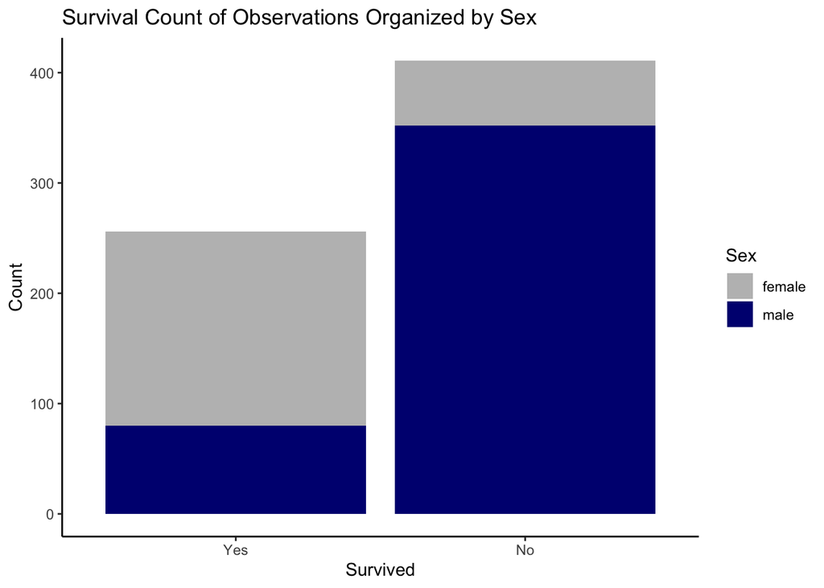

```r
# Create stacked bar chart of sex by survival outcome
ggplot(titanic_train, aes(x = survived, fill = sex)) +
  geom_bar(position = "stack") +
  labs(y = "Count",
       x = "Survived",
       title = "Survival Count of Observations Organized by Sex") +
  scale_fill_manual(name = "Sex",
                      values = c("grey", "navy")) +
  theme_classic()
```

Create one more percent stacked bar chart of `survived`, this time with `fill = pclass`. Do you think passenger class will be a good predictor of the outcome?

> From the results below, it looks like pclass could also be a good predictor of survival status. This is because there are significantly more people with a 3rd class ticket that died than 1st or 2nd class. This is expected because richer people have more resources to survive.

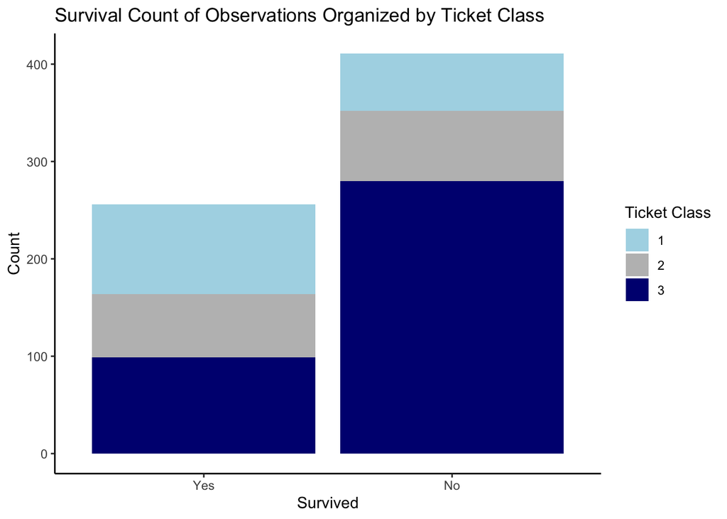

```r
# Create stacked bar chart of ticket class by survival outcome
ggplot(titanic_train, aes(x = survived, fill = pclass)) +
  geom_bar(position = "stack") +
  labs(y = "Count",
       x = "Survived",
       title = "Survival Count of Observations Organized by Ticket Class") +
  scale_fill_manual(
    name = "Ticket Class",
    values = c("lightblue", "grey", "navy")) +
  theme_classic()
```

Why do you think it might be more useful to use a [percent stacked bar chart](https://r-graph-gallery.com/48-grouped-barplot-with-ggplot2) as opposed to a traditional stacked bar chart?

> It may be more useful to use a percent stacked bar chart to assess the proportional difference between the predictors within each outcome.

### Question 3

Using the **training** data set, create a correlation matrix of all continuous variables. Visualize the matrix and describe any patterns you see. Are any predictors correlated with each other? Which ones, and in which direction?

> From the results below, it seems that parch (number of parents / children) and sib_sp (number of siblings / spouses) are positively correlated with each other as signified by a larger, darker blue circle in the correlation matrix. This is expected because both variables describe family size. In other words, passengers with spouses or siblings may be related to passengers with parents or children. This could lead to redundancy in its effect on outcome. To remedy this, we could combine these two predictors into one feature called family_size.

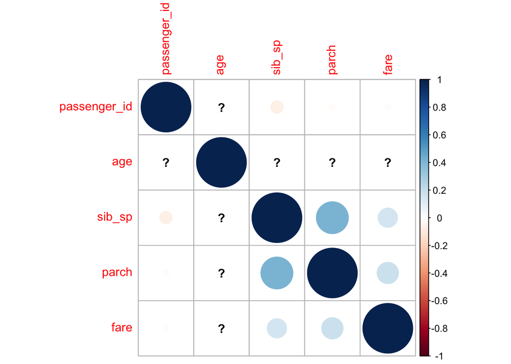

```r
# Select numeric variables within taining set, create correlation matrix, then plot
titanic_train %>%
  select_if(is.numeric) %>%
  cor() %>%
  corrplot()
```

### Question 4

Using the **training** data, create a recipe predicting the outcome variable `survived`. Include the following predictors: ticket class, sex, age, number of siblings or spouses aboard, number of parents or children aboard, and passenger fare.

Recall that there were missing values for `age`. To deal with this, add an imputation step using `step_impute_linear()`. Next, use `step_dummy()` to **dummy** encode categorical predictors. Finally, include interactions between:

- Sex and passenger fare, and
- Age and passenger fare.

You’ll need to investigate the `tidymodels` documentation to find the appropriate step functions to use.

```r
# Create recipe using predictors in question 4.
titanic_recipe <- recipe(survived ~ pclass + sex + age + sib_sp +
                           parch + fare, data = titanic_train) %>%
  step_impute_linear(age) %>% # Interpolate age using linear model
  step_dummy(all_nominal_predictors()) %>% # Encode categorical predictors
  step_interact(terms = ~ sex_male:fare) %>% # Set interaction between sex_male and fare
  step_interact(terms = ~ age:fare) # Set interaction between age and fare
```

### Question 5

Specify a **logistic regression** model for classification using the `"glm"` engine. Then create a workflow. Add your model and the appropriate recipe. Finally, use `fit()` to apply your workflow to the **training** data.

*Hint: Make sure to store the results of `fit()`. You’ll need them later on.*

```r
# Specify logistic regression engine for classification
log_reg <- logistic_reg() %>%
  set_engine("glm") %>%
  set_mode("classification")

# Create workflow for logistic regression with recipe specified above
titanic_wkflow_lr <- workflow() %>%
  add_model(log_reg) %>%
  add_recipe(titanic_recipe)

# Apply workflow to training data
titanic_fit_lr <- fit(titanic_wkflow_lr, titanic_train)
```

### Question 6

**Repeat Question 5**, but this time specify a linear discriminant analysis model for classification using the `"MASS"` engine.

```r
# Specify linear discrminant analysis model engine
lda_mod <- discrim_linear() %>%
  set_mode("classification") %>%
  set_engine("MASS")

# Create workflow for linear discriminant analysis with recipe specified above
titanic_wkflow_lda <- workflow() %>%
  add_model(lda_mod) %>%
  add_recipe(titanic_recipe)

# Apply workflow to training data
titanic_fit_lda <- fit(titanic_wkflow_lda, titanic_train)
```

### Question 7

**Repeat Question 5**, but this time specify a quadratic discriminant analysis model for classification using the `"MASS"` engine.

```r
# Specify quadratic discriminant analysis model engine
qda_mod <- discrim_quad() %>%
  set_mode("classification") %>%
  set_engine("MASS")

# Create workflow for quadratic discriminant analysis with recipe specified above
titanic_wkflow_qda <- workflow() %>%
  add_model(qda_mod) %>%
  add_recipe(titanic_recipe)

# Apply workflow to training data
titanic_fit_qda <- fit(titanic_wkflow_qda, titanic_train)
```

### Question 8

**Repeat Question 5**, but this time specify a *k*-nearest neighbors model for classification using the `"kknn"` engine. Choose a value for *k* to try.

```r
# Specify k-nearest neighbor model for classification engine
knn_mod <- nearest_neighbor(neighbors = 8) %>%
  set_engine("kknn") %>%
  set_mode("classification")

# Create workflow for knn with recipe specified above
titanic_wkflow_knn <- workflow() %>%
  add_model(knn_mod) %>%
  add_recipe(titanic_recipe)

# Apply workflow to training data
titanic_fit_knn <- fit(titanic_wkflow_knn, titanic_train)
```

### Question 9

Now you’ve fit four different models to your training data.

Use `predict()` and `bind_cols()` to generate predictions using each of these 4 models and your **training** data. Then use the metric of **area under the ROC curve** to assess the performance of each of the four models.

```r
# Use logistic regression model created above to predict on training data and attach survived column
pred_lr_train <- predict(titanic_fit_lr, titanic_train, type = "prob") %>%
  bind_cols(titanic_train %>%
              select(survived))

# Use linear discriminant analysis model created above to predict on training data and attach survived column
pred_lda_train <- predict(titanic_fit_lda, titanic_train, type = "prob") %>%
  bind_cols(titanic_train %>%
              select(survived))

# Use quadratic discriminant analysis model created above to predict on training data and attach survived column
pred_qda_train <- predict(titanic_fit_qda, titanic_train, type = "prob") %>%
  bind_cols(titanic_train %>%
              select(survived))

# Use k-nearest neighbor model created above to predict on training data and attach survived column
pred_knn_train <- predict(titanic_fit_knn, titanic_train, type = "prob") %>%
  bind_cols(titanic_train %>%
              select(survived))

# Calculate ROC-AUC for logistic regression
auc_lr_train <- roc_auc(pred_lr_train, truth = survived, .pred_Yes)

# Calculate ROC-AUC for linear discriminant analysis
auc_lda_train <- roc_auc(pred_lda_train, truth = survived, .pred_Yes)

# Calculate ROC-AUC for quadratic discriminant analysis
auc_qda_train <- roc_auc(pred_qda_train, truth = survived, .pred_Yes)

# Calculate ROC-AUC for k-nearest neighbor model
auc_knn_train <- roc_auc(pred_knn_train, truth = survived, .pred_Yes)

# Create table of area under curve results for each model
training_results_df <- rbind(auc_lr_train,
                    auc_lda_train,
                    auc_qda_train,
                    auc_knn_train) %>%
  mutate(method = c("Logistic Regression",
                    "Linear Discriminant Analysis",
                    "Quadratic Discriminant Analysis",
                    "KNN")) %>%
  select(method, .metric, .estimate)

# Print results
training_results_df %>%
  gt() %>%
  tab_header(
    title = "Model Performance Comparison for Training Data"
  )
```

Model Performance Comparison for Training Data

| method | .metric | .estimate |
| --- | --- | --- |
| Logistic Regression | roc_auc | 0.8473949 |
| Linear Discriminant Analysis | roc_auc | 0.8478036 |
| Quadratic Discriminant Analysis | roc_auc | 0.8493528 |
| KNN | roc_auc | 0.9780689 |

### Question 10

Fit all four models to your **testing** data and report the AUC of each model on the **testing** data. Which model achieved the highest AUC on the **testing** data?

```r
# Use logistic regression model created above to predict on testing data and attach survived column
pred_lr_test <- predict(titanic_fit_lr, titanic_test, type = "prob") %>%
  bind_cols(titanic_test %>% select(survived))

# Use linear discriminant analysis model created above to predict on testing data and attach survived column
pred_lda_test <- predict(titanic_fit_lda, titanic_test, type = "prob") %>%
  bind_cols(titanic_test %>% select(survived))

# Use quadratic discriminant analysis model created above to predict on testing data and attach survived column
pred_qda_test <- predict(titanic_fit_qda, titanic_test, type = "prob") %>%
  bind_cols(titanic_test %>% select(survived))

# Use k-nearest neighbor model created above to predict on testing data and attach survived column
pred_knn_test <- predict(titanic_fit_knn, titanic_test, type = "prob") %>%
  bind_cols(titanic_test %>% select(survived))

# Calculate ROC-AUC for logistic regression
auc_lr_test <- roc_auc(pred_lr_test, truth = survived, .pred_Yes)

# Calculate ROC-AUC for linear discriminant analysis
auc_lda_test <- roc_auc(pred_lda_test, truth = survived, .pred_Yes)

# Calculate ROC-AUC for quadratic discriminant analysis
auc_qda_test <- roc_auc(pred_qda_test, truth = survived, .pred_Yes)

# Calculate ROC-AUC for k-nearest neighbor model
auc_knn_test <- roc_auc(pred_knn_test, truth = survived, .pred_Yes)

# Create table of area under curve results for each model
test_results_df <- rbind(auc_lr_test,
                    auc_lda_test,
                    auc_qda_test,
                    auc_knn_test) %>%
  mutate(method = c("Logistic Regression",
                    "Linear Discriminant Analysis",
                    "Quadratic Discriminant Analysis",
                    "KNN")) %>%
  select(method, .metric, .estimate)

# Print results
test_results_df %>%
  gt() %>%
  tab_header(
    title = "Model Performance Comparison for Testing Data"
  )
```

Model Performance Comparison for Testing Data

| method | .metric | .estimate |
| --- | --- | --- |
| Logistic Regression | roc_auc | 0.8681749 |
| Linear Discriminant Analysis | roc_auc | 0.8713768 |
| Quadratic Discriminant Analysis | roc_auc | 0.8603809 |
| KNN | roc_auc | 0.8656892 |

Using your top-performing model, create a confusion matrix and visualize it. Create a plot of its ROC curve.

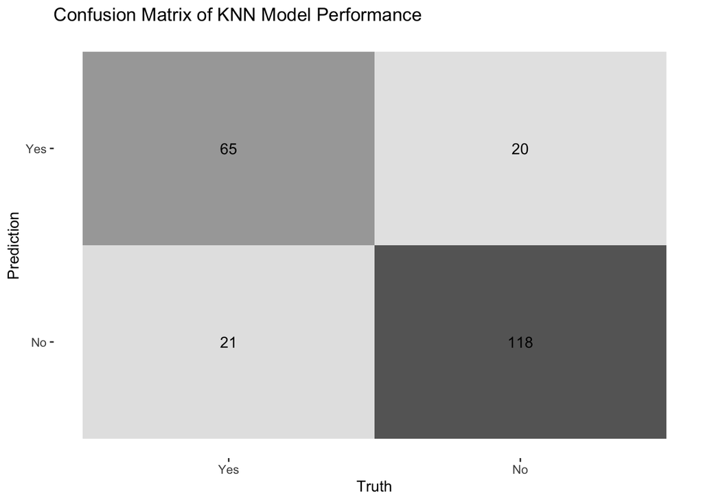

```r
# Create confusion matrix for knn model performance on testing data
conf_matrix <- predict(titanic_fit_knn, titanic_test, type = "class") %>%
  bind_cols(titanic_test %>% select(survived)) %>%
  conf_mat(truth = survived, estimate = .pred_class)

# Plot confusion matrix
conf_matrix %>%
  autoplot(type = 'heatmap') +
  ggtitle("Confusion Matrix of KNN Model Performance")
```

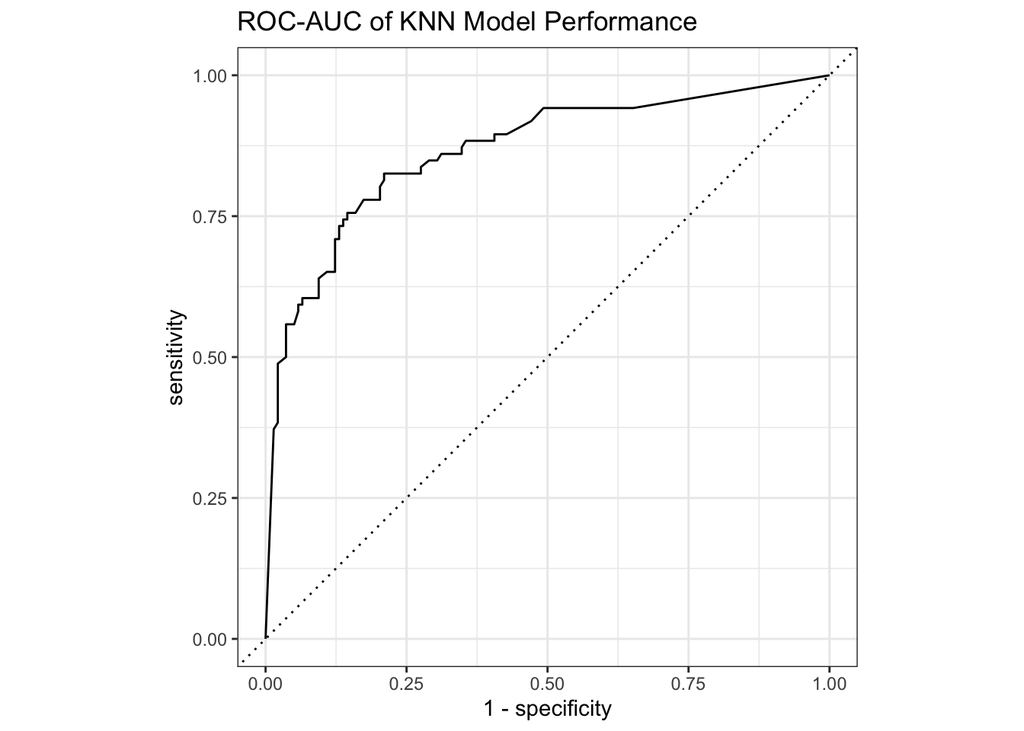

```r
# Create ROC-AUC for knn model
roc_curve(pred_knn_test, truth = survived, .pred_Yes) %>%
  autoplot() +
  ggtitle("ROC-AUC of KNN Model Performance")
```

How did your best model perform? Compare its **training** and **testing** AUC values. If the values differ, why do you think this is so?

### Question 11

In a binary classification problem, let $p$ represent the probability of class label $1$, which implies that $1 - p$ represents the probability of class label $0$. The *logistic function* (also called the “inverse logit”) is the cumulative distribution function of the logistic distribution, which maps a real number *z* to the open interval $(0, 1)$.

Given that:

$$p(z)=\frac{e^z}{1+e^z}$$

Prove that the inverse of a logistic function is indeed the *logit* function:

$$z(p)=ln\left(\frac{p}{1-p}\right)$$

To prove that the inverse of p(z) is the logit function, we need to isolate z using the following steps:

$$p(z){(1+e^z)}={e^z}$$
$${p+pe^z}={e^z}$$
$$p=e^z-pe^z$$
$$p=e^z(1-p)$$
$$e^z=\frac{p}{1-p}$$
Now that we almost have z alone, we can take the log of both sides to turn it into the logit function.
$$z=ln\left(\frac{p}{1-p}\right)$$